# PA1_template.Rmd

Friday, August 15, 2014

Loading and preprocessing the data.

```r
download.file("http://d396qusza40orc.cloudfront.net/repdata%2Fdata%2Factivity.zip",
              "data.zip", quiet = TRUE, mode = "wb")
unzip("data.zip")

activity = read.csv("activity.csv", header = TRUE)
```

Eliminate NA from activity.

```r
newActivity <- activity[!is.na(activity$steps),]
```

Make a histogram of the total number of steps taken each day.

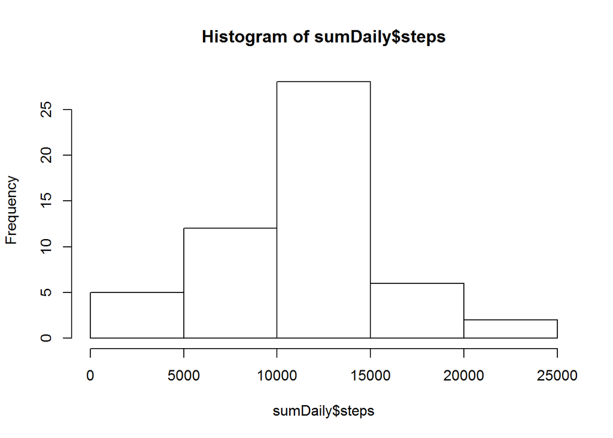

```r
sumDaily<-aggregate(newActivity$steps, by = list(Date=newActivity$date), FUN =sum)

names(sumDaily)[2] <-"steps"

hist(sumDaily$steps)
```

Calculate and report the mean and median total number of steps taken per day.

```r
mean(sumDaily$steps)
```

```
## [1] 10766
```

```r
median(sumDaily$steps)
```

```
## [1] 10765
```

Identify the average daily activity pattern.

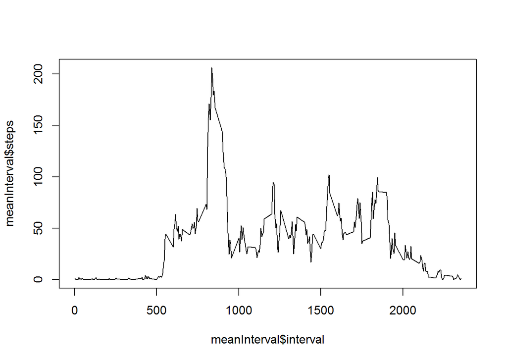

```r
meanInterval<-aggregate(newActivity$steps, by = list(interval=newActivity$interval), FUN =mean)
names(meanInterval)[2] <-"steps"

plot(meanInterval$interval,meanInterval$steps,type="l")
```

Find Which 5-minute interval, on average across all the days in the dataset, contains the maximum number of steps.

```r
tf<-meanInterval$steps== max(meanInterval$steps)

which(tf)
```

```
## [1] 104
```

```r
meanInterval[which(tf),]
```

```
##     interval steps
## 104      835 206.2
```

Imputing missing values:

Note that there are a number of days/intervals where there are missing values (coded as NA). The presence of missing days may introduce bias into some calculations or summaries of the data.

```
Calculate and report the total number of missing values in the dataset (i.e. the total number of rows with NAs).
```

```r
NAActivity <- activity[is.na(activity$steps),]
nrow(NAActivity)
```

```
## [1] 2304
```

The result is the same as the following:

```r
nrow(activity)  - nrow(newActivity)
```

```
## [1] 2304
```

Using the mean for that 5-minute interval to fill/impute the mising value.

```r
ImputedActivity<- activity

n.length <- nrow(ImputedActivity)

for (i in 1:n.length)
{
  if (is.na(ImputedActivity[i,1]) )
  {
    s1 <- subset(activity, activity$interval == ImputedActivity[i,3], select = c(steps,interval) )
    ImputedActivity[i,1] <- mean(s1$steps, na.rm = TRUE)
  }

}
```

```
With new data set to make a histogram of the total number of steps taken each day and Calculate and report the mean and median total number of steps taken per day.
```

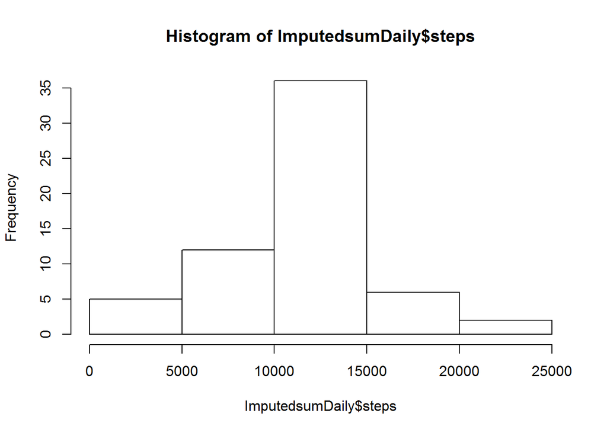

```r
ImputedsumDaily<-aggregate(ImputedActivity$steps, by = list(Date=ImputedActivity$date), FUN =sum)

names(ImputedsumDaily)[2] <-"steps"

hist(ImputedsumDaily$steps)
```

New mean and median for imputed data.

```r
mean(ImputedsumDaily$steps)
```

```
## [1] 10766
```

```r
median(ImputedsumDaily$steps)
```

```
## [1] 10766
```

Mean and median differnces.

```r
meanDifference <- mean(ImputedsumDaily$steps) -mean(sumDaily$steps)
medianDifference <- median(ImputedsumDaily$steps) - median(sumDaily$steps)

meanDifference
```

```
## [1] 0
```

```r
medianDifference
```

```
## [1] 1.189
```

histogram comparison between Original and Imputed.

Step 1: Adding new type column Step 2: Combining two dataframes into one.

```
## stat_bin: binwidth defaulted to range/30. Use 'binwidth = x' to adjust this.
```

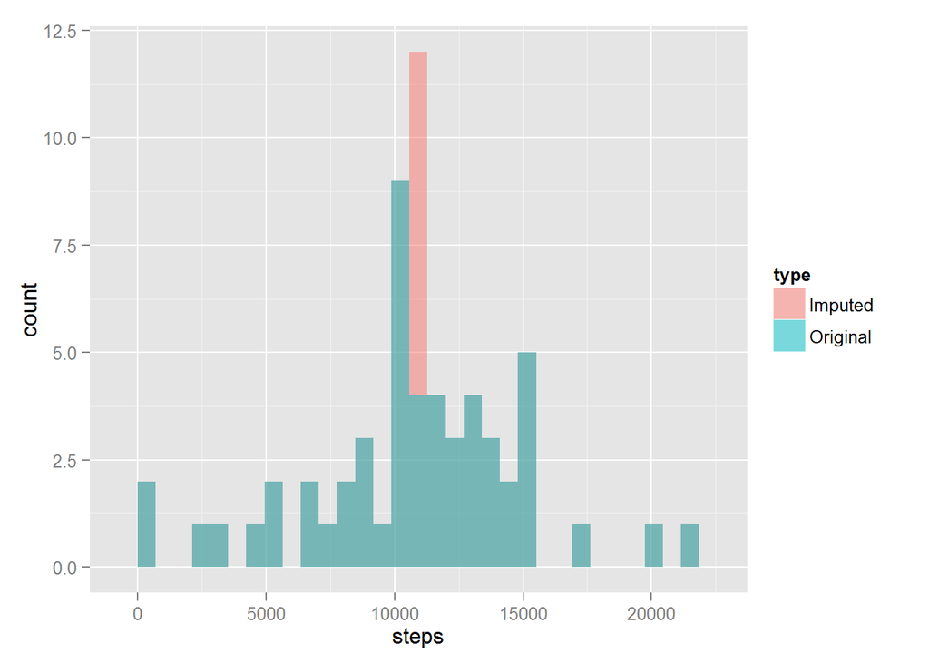

```r
library(ggplot2)

sumDaily$type <-'Original'
ImputedsumDaily$type <- 'Imputed'

df_combined <- rbind(sumDaily, ImputedsumDaily)

ggplot(df_combined, aes(steps, fill = type)) +
geom_histogram(alpha = 0.5,  position = 'identity')
```

Identify the differences in activity patterns between weekdays and weekends.

Create a new factor variable in the dataset with two levels - “weekday” and “weekend” indicating whether a given date is a weekday or weekend day.

```r
weekday <- weekdays(as.Date(ImputedActivity$date, "%Y-%m-%d"))

head(weekday)
```

```
## [1] "Monday" "Monday" "Monday" "Monday" "Monday" "Monday"
```

```r
for (i in 1:length(weekday)) {
    if ((weekday[i] == "Saturday") | (weekday[i] == "Sunday"))
        weekday[i] = "weekend" else weekday[i] = "weekday"
}

ImputedActivity$weekday <- as.factor(weekday)
```

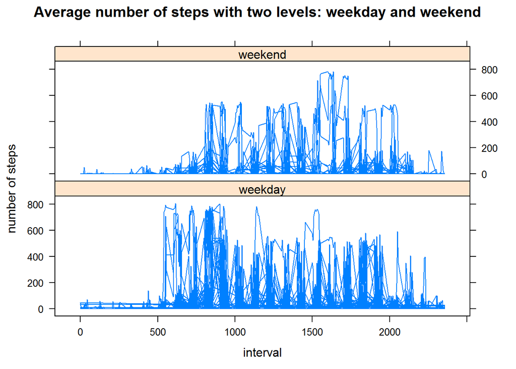

```r
LevelmeanInterval<-aggregate(ImputedActivity$steps, by = list(interval=ImputedActivity$interval, level=ImputedActivity$weekday), FUN =mean)

names(LevelmeanInterval)[3] <-"steps"

library(lattice)
xyplot(steps ~ interval | weekday, data = ImputedActivity, layout = c(1, 2), type="l", ylab = "number of steps",
    main = "Average number of steps with two levels: weekday and weekend")
```